# autoLIMR: Automated workflow for incorporation and evaluation of data uncertainty in ecological networks

Gemma Gerber

2023

# 1 Introduction

Data variability is an inherent part of ecosystem models. To include data uncertainty in model outputs, a popular method is to solve multiple plausible representations of the model. The multiple plausible representations each represent a plausible configuration of flow values given the ecological input constraints. Together, the ensemble of plausible model representations capture the inherent ecological variability, enabling increased realism of model outputs and interpretations.

Multiple plausible ecological networks are frequently solved using linear inverse modelling with Markov Chain Monte Carlo (LIM-MCMC) with R packages [LIM](https://cran.r-project.org/web/packages/LIM/index.html) (van Oevelen et al., 2010), and embedded R package [limSolve](https://cran.r-project.org/web/packages/limSolve/index.html) (Soetaert et al., 2009). To use these packages, all input data on network structure (compartments and directed flows) and flow constraints (lower and upper bounds) need to be manually coded into linear equations and declared in particular sections in a LIM-readable text file, the so-called LIM declaration file (van Oevelen et al., 2010). For small networks, the manual construction of a LIM declaration file is straightforward but becomes less manageable in terms of complexity and time as network size increases.

Further, the evaluation of how well the multiple plausible food webs represent the ecological input data (model quality) needs to be assessed. In ecological modelling, model quality is often assessed with traceplots (Van den Meersche et al., 2009; van der Heijden et al., 2020) and interpretations of convergence of each flow mean and standard deviation values to a stable value (Bell et al., 2017; de Jonge et al., 2020) or not reported at all. While these diagnostics provide some indication of LIM-MCMC algorithm performance, they neglect critical measures of algorithm performance, such as precise measures of mixing or autocorrelation (the degree to which samples are correlated), limiting the confidence that the model outputs are fully representative of the ecological input data.

To overcome the hurdles of input file construction, and evaluation of multiple plausible networks in ecological modelling, we developed R package **autoLIMR**: an inclusive and automated workflow to (1) create input files, (2) generate multiple plausible food web flow values, (3) pack solved flow values into network objects for network analysis and visualisation, and (4) evaluate solved flow values (‘model quality’) with established MCMC convergence diagnostics. We describe the latest package version and apply it to an empirically inspired four-compartment food web time series of four seasonal time steps (‘Summer’, ‘Autumn’, ‘Winter’, ‘Spring’).

While our example focuses on ecological networks, **autoLIMR** applications is flexible and easily adaptable to a variety of system science disciplines. By removing barriers in the network construction and evaluation process, **autoLIMR** can improve the uptake of LIM techniques in network modelling, and the quality of constructed networks.

# 2 Software Requirements & Getting Started

The latest version of **autoLIMR** can be installed from [GitHub](https://github.com/gemmagerber/autoLIMR). **autoLIMR** dependencies are automatically installed, including cellranger (>= 1.1.0) (Bryan, 2016), readxl (>= 1.4.1) (Wickham and Bryan, 2022), and utils (>= 4.2.1) (R Core Team, 2022).

```r
devtools::install_github("gemmageber/autoLIMR")
library(autoLIMR)
```

# 3 **autoLIMR** workflow overview

An ecosystem network consists of the biomass of each functional group or species, their energy or nutrient requirements and outputs, and their trophic interactions. These data are collected before using **autoLIMR** (e.g., see Fath et al., 2007; Scharler & Borrett, 2021 for instructions on network construction). The first step to using **autoLIMR** is to consolidate the data into two Excel workbooks (‘.xlsx’ file extension) containing network input data on compartments, biomasses, and metabolic constraints (Workbook 1), and the proportional diet and egestive flows between compartments (‘who eats who and by how much’, Workbook 2) (Figure 3.1). After that, the **autoLIMR** workflow consists of three core R functions. The first function, `autoGen()`, translates network data into LIM declaration files compatible with R packages [LIM](https://cran.r-project.org/web/packages/LIM/index.html) and [limSolve](https://cran.r-project.org/web/packages/limSolve/index.html). Function `autoGen()` imports network data from the two pre-defined Excel workbooks, translates the data into linear equations describing network topography and parameters, arranges them in multiple ‘LIM Declaration files’ (‘.R’ file extension) each representing one network model, and writes these files to the computer hard drive.

The second core function, `multi_net()`, solves multiple plausible networks for each network model described by a LIM declaration file. Function `multi_net()` uses LIM-MCMC methods from R packages [LIM](https://cran.r-project.org/web/packages/LIM/index.html) and [limSolve](https://cran.r-project.org/web/packages/limSolve/index.html) to simulate a user-defined number of plausible solutions valid within the ecologically derived input data constraints. With the `multi_net()` function, users can toggle the LIM-MCMC algorithm parameters (starting point, jump size, iterations). The result of the `multi_net()` function is an R list of combined model output items, including 1) metadata, 2) a table of solved food web flow values, and 3) solved values packed into network objects.

The third and final core function, `mcmc_diags()`, evaluates the quality of the multiple plausible networks, i.e., how well the networks represent the input data constraints, using several Markov Chain Monte Carlo (MCMC) convergence diagnostics. To statistically assess MCMC convergence of every flow of the multiple plausible networks, function `mcmc_diags()` applies six different MCMC convergence diagnostics and returns the output in a list. The convergence diagnostic outputs, when assessed together, provide a holistic assessment of three main criteria of convergence (stationarity, mixing, and sampling efficiency). An additional function, `mcmc_plots()`, plots five visual diagnostics for a single flow simultaneously. This is useful to assess convergence of a few flows of research interest, rather than all flows at once.

[figure not shown]

Figure 3.1: *Main workflow of R package **autoLIMR**. First, network data is consolidated into two main workbooks. Next, function `autoGen()` constructs LIM declaration files for each network described in the input workbooks. Function `multi_net()` solves multiple plausible networks for each network defined by a LIM declaration file. Model quality of the multiple plausible networks is then assessed with visual (`mcmc_plots()`) and statistical (`mcmc_diag()`) Markov Chain Monte Carlo (MCMC) convergence diagnostics. Once the multiple plausible networks have been deemed ‘good’ quality, network visualisation and analysis can be applied to the multiple plausible networks using existing R packages*

# 4 User Guide

We describe how to use **autoLIMR** using a theoretical four-compartment network, describing the network interactions and flow constraints over seasonal time-steps of Winter, Spring, Summer, and Autumn (Figure 4.1).

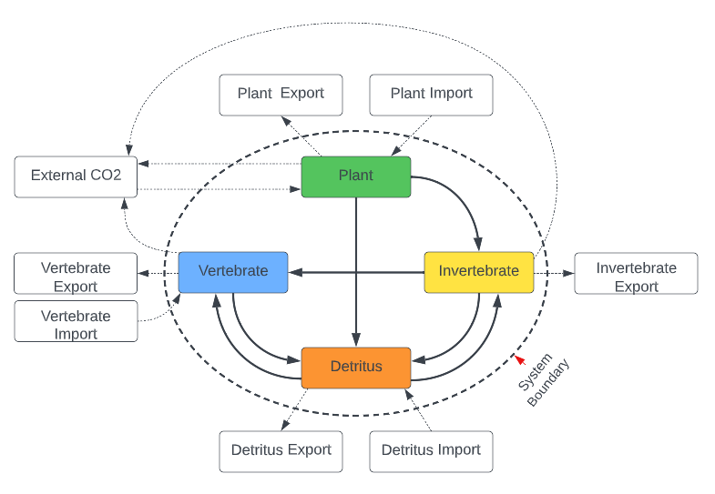

Figure 4.1: *Conceptual four-compartment network with flows describing exchanges between compartments within and across a defined system boundary*

## 4.1 Data requirements

Prior to using **autoLIMR**, all network data are calculated to a specific model currency or defined as proportions of another variable (see Fath et al., 2007; Scharler and Borrett, 2021 for details). In our example, the model currency is in units of carbon, i.e., mg C·m<sup>–2</sup> for compartment biomasses, and mg C·m<sup>–2</sup>·day<sup>–1</sup> for flows.

## 4.2 Network construction with **autoLIMR**

Prior to using **autoLIMR**, all network data are calculated to a specific model currency or defined as simple proportions of another variable (Fath et al., 2007; Scharler and Borrett, 2021). In our example, the model currency is in units of carbon, i.e., mg C·m<sup>–2</sup> for compartment biomasses, and mg C·m<sup>–2</sup>·day<sup>–1</sup> for flows. This informtion will be used to create LIM declaration files, which are the necessary input files for solving mulriple plausible networks with [LIM](https://cran.r-project.org/web/packages/LIM/index.html) (van Oevelen et al., 2010), and embedded R package [limSolve](https://cran.r-project.org/web/packages/limSolve/index.html) (Soetaert et al., 2009).

**autoLIMR** requires the user to differentiate and store the required network data in two separate Excel documents: 1) contains all ‘Network Input Data’, and 2) contains all internal compartment interactions in ‘Adjacency Matrix’. In each document, each sheet corresponds to one network, and each sheet should be named uniquely, and matched identically between the two documents. Both documents should be saved in the active R session working directory. We go through each document in detail below.

### 4.2.1 Network Input Data Workbook

The first workbook contains network information on: 1) internal compartment names, 2) their respective biomasses, and 3) compartment-specific metabolic constraints. Each sheet will contain all the network information relating to that specific network (Figure 4.2).

**autoLIMR** requires the final list of internal compartments to be listed under column ‘Compartment’, and respective biomasses under the column ‘Biomass’. The network information is listed under separate column headings, with each row hosting the information for a particular compartment. The network information describes lower and upper bounds for inputs and outputs of each living compartment if these values are available. If only equalities exist for the particular parameter, the should be entered as both lower and upper values. **autoLIMR** understands compartment inputs and outputs as Consumption (Q) (or the equivalent gross primary production (GPP) in the case of primary producers), Production (P) (or the equivalent Net Primary Production (NPP) in the case of primary producers), unused material/energy (egestion and mortality combined) (U), and assimilation efficiency (AE) (as a fraction of total consumption). The values can be absolute values, or simple proportions of another variable e.g., `Plant_R = 0.02 * Plant_NPP`. If the metabolic parameter values are not available, the user leaves these blank, and no constraints for Q, P, U, or AE (or primary producer equivalents) are generated by **autoLIMR**.

For all compartments that feature imports (*IM*) and exports (*EX*) across the system boundary the user inputs lower and upper inequalities in separate columns. If a compartment receives an import or export, but the inequalities are not known, the user inputs a `1` in the respective column.

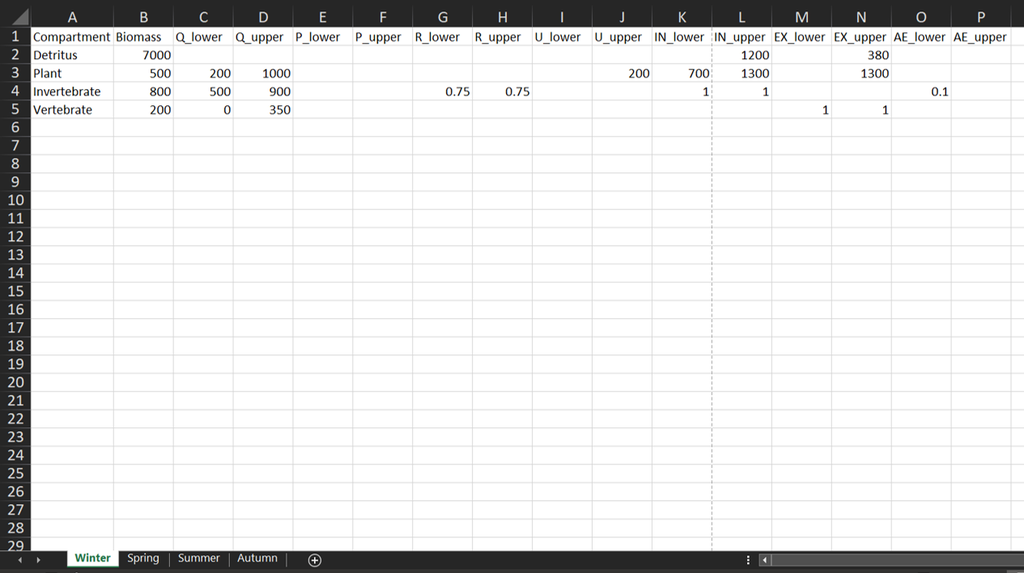

Figure 4.2: *Network input data sheet Winter example, showing pre-calculated data describing the food web model compartments, biomasses, and metabolic constraints entered a named Excel spreadsheet. Column headings describe the metabolic data in the column, and each row corresponding to one compartment. Each named spreadsheet corresponds to a seperate network (‘Winter’, ‘Spring’, ‘Summer’, ‘Autumn’), each containing all relevant network-specific information. **autoLIMR** accepts both character and numeric input from the spreadsheet.*

To view the network input data for all seasons, the example network data provided with **autoLIMR** can be downloaded from the [autoLIMR Supplemental Information GitHub repository](https://github.com/gemmagerber/autoLIM_Supplemental_Information), or fetched with `demo_net_input()`. The demo network data input is a list of four data tables containing network data input for ‘Winter’, ‘Spring’, ‘Summer’, and ‘Autumn’ four-compartment networks.

```r
demo_net_input()
```

```
#> $Summer
#>   Compartment Biomass Consumption_lower Consumption_upper Production_lower
#> 1         Det 10000.2                NA                NA             <NA>
#> 2       Plant   800.0              1100              2600  0.6 * Plant_GPP
#> 3      Invert  2000.0               100              3000   0.4 * Invert_Q
#> 4        Vert    55.0                NA                NA             <NA>
#>   Production_upper Respiration_lower Respiration_upper Unused_energy_lower
#> 1             <NA>              <NA>              <NA>                  NA
#> 2  0.8 * Plant_GPP   0.4 * Plant_NPP   0.7 * Plant_NPP                  NA
#> 3   0.6 * Invert_Q      1 * Invert_P              <NA>                  NA
#> 4             <NA>              0.75              0.75                  NA
#>   Unused_energy_upper Imports_lower Imports_upper Exports_lower Exports_upper
#> 1                <NA>             1            NA             1            NA
#> 2                <NA>             1            NA             1            NA
#> 3                <NA>            NA            NA            NA            NA
```

[output cut: 57 more lines]

### 4.2.2 Adjacency Matrix Data Workbook

In the ‘Adjacency Matrix Input’ workbook, flows between source (row *i*) and recipient (column *j*) are defined by `1` (Figure 4.3). If the proportions of compartmental inflow from different sources are provided, these can instead be entered as a constraint in the form of *lower value, upper value*. For example, `0.2,0.5` indicates that a specific flow comprises 20 - 50 % of compartment *j*’s total consumptive input. If only the lower proportion is known, it can be entered as *lower value, 1*, e.g., `0.2, 1` indicates that the flow contributes a minimum of 20 % and a maximum of 100% to total consumption. If only the upper diet proportion is known, it can be entered as the constraint *upper value* or *0, upper value* (e.g., `0.6` or `0, 0.6` – indicating that the flow contributes a maximum of 60 % to total consumption). R packages LIM and limSolve do not use flow values below or equal to zero (van Oevelen et al., 2010).

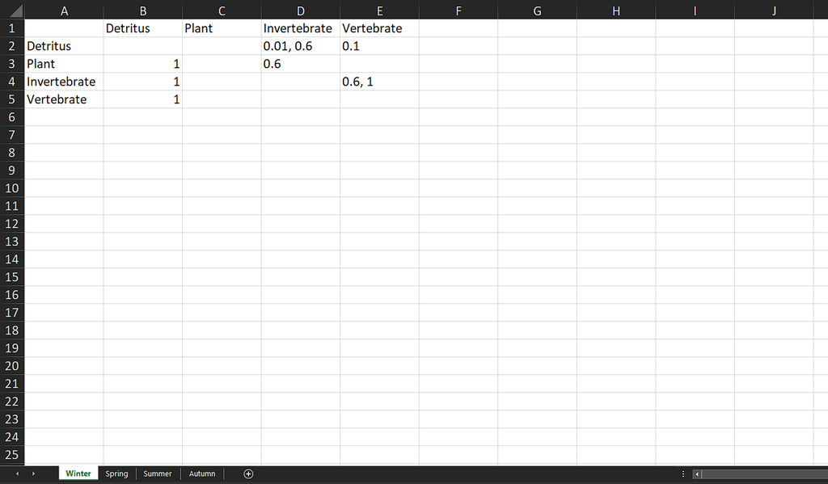

Figure 4.3: *Adjacency matrix data Winter example, describing flows and flow constraints from compartment in row *i* to compartment in column *j*. Each named spreadsheet corresponds to a seperate network (‘Winter’, ‘Spring’, ‘Summer’, ‘Autumn’), each containing all relevant network-specific information. **autoLIMR** accepts both character and numeric input from the spreadsheet.*

To view the adjacency matrix data for all seasons, the example adjacency matrix data provided with **autoLIMR** can be downloaded from the [autoLIMR Supplemental Information GitHub repository](https://github.com/gemmagerber/autoLIM_Supplemental_Information), or fetched with `demo_adj_mat()`. The demo adjacency matrix input is a list of four data tables containing adjacency matrices for ‘Winter’, ‘Spring’, ‘Summer’, and ‘Autumn’ four-compartment networks. Each adjacency matrix describes internal flows of energy/material from compartment in row *i* to compartment in column *j*.

```r
demo_adj_mat()
```

```
#> $Summer
#>        X Det Plant Invert Vert
#> 1    Det  NA    NA      1   NA
#> 2  Plant   1    NA      1   NA
#> 3 Invert   1    NA     NA    1
#> 4   Vert   1    NA     NA   NA
#>
#> $Autumn
#>        X Det Plant Invert Vert
#> 1    Det  NA    NA      1   NA
#> 2  Plant   1    NA      1   NA
#> 3 Invert   1    NA     NA    1
#> 4   Vert   1    NA     NA   NA
#>
#> $Winter
#>        X Det Plant    Invert   Vert
#> 1    Det  NA    NA 0.01, 0.6    0.1
#> 2  Plant   1    NA       0.6   <NA>
#> 3 Invert   1    NA      <NA> 0.6, 1
#> 4   Vert   1    NA      <NA>   <NA>
#>
#> $Spring
#>        X Det Plant Invert Vert
#> 1    Det  NA    NA      1   NA
#> 2  Plant   1    NA      1   NA
#> 3 Invert   1    NA     NA    1
#> 4   Vert   1    NA     NA   NA
```

### 4.2.3 `autoGen()`: write LIM declaration files into folders in working directory

Once both workbooks have been populated, **autoLIMR** uses the function `autoGen()` to take the information from both workbooks, and output ready to use LIM declaration file in RStudio script format (*.R*). **autoLIMR** creates two folders in the working directory: 1) ‘autoLIMR Weighted Network LIMfiles’ and 2) ‘autoLIMR Unweighted Network LIMfiles’.

The exact nature of translation depends on three main `autoGen()` arguments: 1) whether respiration from living compartments to an external CO2 sink is included in the network (LOGICAL, default `respiration = TRUE`), 2) whether each compartment is living or non-living (character vector, default `NLNode = NULL`), and 3) whether each compartment sources its energy from outside the system boundary e.g., primary producers in ecological networks (character vector, default `primary_producer = NULL`).

A non-negotiable `autoGen()` argument is `force`, which is asking the user for permission to write to the working directory. By default, `force = FALSE`. The user will need to provide consent for **autoLIMR** to write LIMfiles in their respective folders in the working directory by setting `force = TRUE`.

```r
autoGen(
  net_data_input = "my_network_input_data.xlsx",
  adj_mat_input = "my_network_adj_mat_data.xlsx",
  NLNode = NULL,
  primary_producer = NULL,
  respiration = TRUE,
  author = "Jane Doe",
  force = TRUE
)
```

A handy demo of `autoGen()` is included in this package, using the demo datasets from `demo_net_input()` and `demo_adj_mat()`. Users can simply run the code below, with the `net_data_input = "demo"` and `adj_mat_input = "demo"` to automatically pull the respective demo datasets into `autoGen()` and write the respective folders of LIM declaration files to the working directory.

```r
autoGen(
  net_data_input = "demo",
  adj_mat_input = "demo",
  NLNode = "Detritus",
  primary_producer = "Plant",
  respiration = TRUE,
  author = "autoLIMR authors",
  force = TRUE
)
```

An example of the Winter weighted LIM declaration output from **autoLIMR**:

```r
! Weighted Network
! Network LIM Declaration File
! Composed with autoLIMR
! Author: Gemma Gerber
! Date: 2022-10-28

! Respiration included: Yes
! U included: Yes

! Living compartments: 3
! Non-living compartments: 1
! External compartments: 7
! Boundary flows: 10
! Internal flows: 7

! Abbreviations
! GPP = Gross Primary Production (Primary Producers only)
! Q = Consumption
! NPP = Net Primary Production (Primary Producers only)
! P = Production
! R = respiration
! U = Passive flows to non-living compartments/Unassimilated material
! AE = Assimilation Efficiency
! IM = Import flow
! EX = Export Flow
! NLNode = Non-living compartment

### COMPARTMENTS

Invertebrate = 800.00
Plant = 500.00
Vertebrate = 200.00
DetritusNLNode = 7000.00

### END COMPARTMENTS

### EXTERNALS

CO2
DetritusNLNodeInput
InvertebrateInput
PlantInput
DetritusNLNodeExport
PlantExport
VertebrateExport

### END EXTERNALS

### VARIABLES

! Consumption (Q) / Gross Primary Production (GPP) Variables

Invertebrate_Q = Flowto(Invertebrate) - Invertebrate_IN
Plant_GPP = Flowto(Plant) - Plant_IN
Vertebrate_Q = Flowto(Vertebrate)

! Production (P/NPP) Variables

Invertebrate_P = Flowfrom(Invertebrate) - Invertebrate_R - Invertebrate_U
Plant_NPP = Flowfrom(Plant) - Plant_R - Plant_U - Plant_EX
Vertebrate_P = Flowfrom(Vertebrate) - Vertebrate_R - Vertebrate_U - Vertebrate_EX

! Unused Energy/Material (U) Variables

Invertebrate_U = Flowto(Invertebrate) - Invertebrate_P - Invertebrate_R
Plant_U = Flowto(Plant) - Plant_NPP - Plant_R - Plant_EX
Vertebrate_U = Flowto(Vertebrate) - Vertebrate_P - Vertebrate_R - Vertebrate_EX

! Assimilation Efficiency (AE) Variables

Invertebrate_AE = Invertebrate_P + Invertebrate_R
Vertebrate_AE = Vertebrate_P + Vertebrate_R

### END VARIABLES

### FLOWS

! GPP flows

Plant_GPP: CO2 -> Plant

! Respiration flows

Plant_R: Plant -> CO2
Invertebrate_R: Invertebrate -> CO2
Vertebrate_R: Vertebrate -> CO2

! Import flows

DetritusNLNode_IM: DetritusNLNodeImport -> DetritusNLNode
Invertebrate_IM: InvertebrateImport -> Invertebrate
Plant_IM: PlantImport -> Plant

! Export flows

DetritusNLNode_EX: DetritusNLNode -> DetritusNLNodeExport
Plant_EX: Plant -> PlantExport
Vertebrate_EX: Vertebrate -> VertebrateExport

! Adjacency Matrix flows

DetritusNLNode_Q_Invertebrate: DetritusNLNode -> Invertebrate
DetritusNLNode_Q_Vertebrate: DetritusNLNode -> Vertebrate
Invertebrate_Q_Vertebrate: Invertebrate -> Vertebrate
Invertebrate_U_DetritusNLNode: Invertebrate -> DetritusNLNode
Plant_Q_Invertebrate: Plant -> Invertebrate
Plant_U_DetritusNLNode: Plant -> DetritusNLNode
Vertebrate_U_DetritusNLNode: Vertebrate -> DetritusNLNode

### END FLOWS

### INEQUALITIES

! Network Data Input Inequalities

Plant_GPP > 200.00
Invertebrate_Q > 500.00
Plant_GPP < 1000.00
Invertebrate_Q < 900.00
Vertebrate_Q < 350.00
Invertebrate_R > 0.75
Invertebrate_R < 0.75
Plant_U < 200.00
Plant_IM > 700.00
DetritusNLNode_IM < 1200.00
Plant_IM < 1300.00
DetritusNLNode_EX < 380.00
Plant_EX < 1300.00
Invertebrate_AE > Invertebrate_Q * 0.50
Vertebrate_AE > Vertebrate_Q * 0.20
Invertebrate_AE > Invertebrate_Q * 0.80
Vertebrate_AE > Vertebrate_Q * 0.30

! Adjacency Matrix Inequalities

DetritusNLNode_Q_Invertebrate = Invertebrate_Q * [0.01,0.6]
Plant_Q_Invertebrate < Invertebrate_Q * 0.6
Invertebrate_Q_Vertebrate = Vertebrate_Q * [0.6,1]

### END INEQUALITIES
```

## 4.3 Calculating multiple plausible networks

Function `multi_net()` uses LIM-MCMC methods from R packages [LIM](https://cran.r-project.org/web/packages/LIM/index.html) (van Oevelen et al., 2010), and [limSolve](https://cran.r-project.org/web/packages/limSolve/index.html) (Soetaert et al., 2009) to simulate a user-defined number of plausible solutions valid within the ecologically derived input data constraints. With the `multi_net()` function, users can toggle the LIM-MCMC algorithm parameters (starting point, jump size, iterations). The result of the `multi_net()` function is an R list of combined model output items, including 1) metadata, 2) a table of solved food web flow values, and 3) solved values packed into network objects.

```r
set.seed(1)                         # Initialise pseudorandom number generator
summer_nets <- multi_net(
  file =  ‘Winter_Weighted_Network_LIMfile.R’, # The LIM declaration file
  x0 = NULL,                                   # The algorithm starting solution
  iter = 5000,                                 # Define the number of iterations
  jmp = 20,                                   # Define the jump size
  pack = TRUE                                  # Pack into network objects
)
```

## 4.4 Evaluate model quality

**autoLIMR** allows users to evaluate model quality using Markov Chain Monte Carlo (MCMC) convergence diagnostics. Together, the diagnostics report three core aspects of MCMC convergence: 1) stationarity - whether the flow has successfully targeted the underlying solution space (posterior) distribution; 2) mixing - whether the samples are effectively integrating over the posterior probability; and 3) sampling intensity - whether enough samples (iterations) have been returned to describe the posterior distribution adequately.

### 4.4.1 Visual MCMC diagnostics

**autoLIMR** consist of five different MCMC convergence diagnostic plots for each variable (flow) of the multiple plausible food web networks, namely:

- Trace plot with `trace_plot()`
- Kernel density plot with `dens_plot()`
- Running mean plot with `runmean_plot()`
- Geweke Plot with `geweke_plot()`
- Autocorrelation plot with `autocorr_plot()`

Each plot assesses a different aspect of MCMC convergence and can be assessed together to provide an enhanced evaluation. While each **autoLIMR** visual diagnostic plot function can be used independently, a convenient summary plot function, `mcmc_plots()`, visualises all diagnostics simultaneously

```r
# Fetch LIM declaration file path
fpath <- system.file("example_limfiles",
              "Winter_Weighted_Network_LIMfile.R",
              package = "autoLIMR")

# Solve multiple plausible networks
# Generates an object of class 'multi_net_object'
set.seed(1)
winter_networks <- multi_net(
  file = fpath,
  iter = 5000,
  jmp = 20,
  x0 = NULL
)
```

```
#> Initial solution (x0) calculated using default LSEI algorithm (Haskell
#> and Hanson 1981).  Solving multiple plausible network values (this may
#> take a while)...
#>    user  system elapsed
#>    0.11    0.07    0.15
#> Multiple plausible network values solved.
#> Packing multiple plausible values into network objects...
#> Multiple plausible values solved and packed into network objects.
#>
```

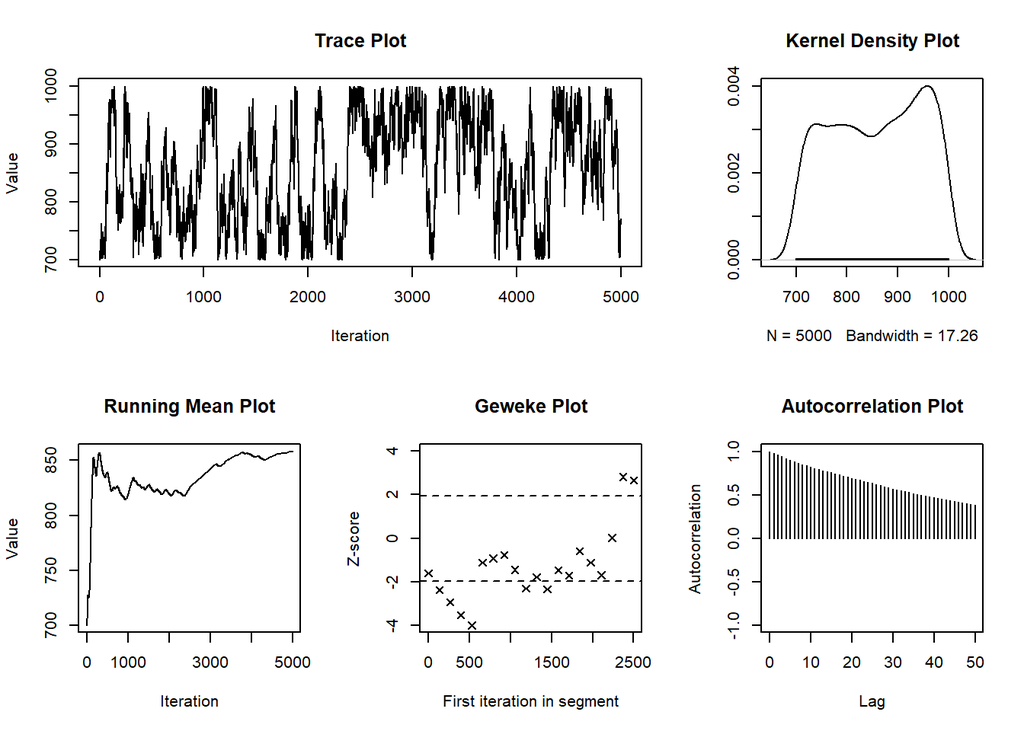

```r
# Plot visual MCMC convergence diagnostics for flow 'Plant_GPP'
# With figure titles
mcmc_plots(x = winter_networks, flow = "Plant_GPP", addtitle = TRUE)
```

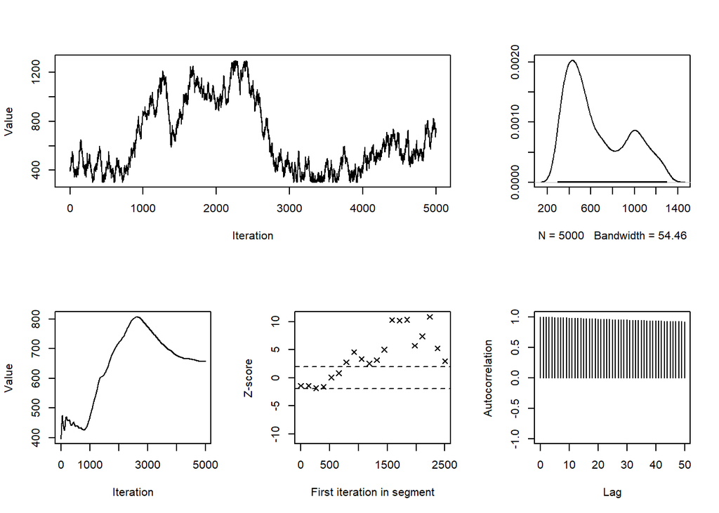

```r
# Plot visual MCMC convergence diagnostics for flow 'Plant_EX'
# Without figure titles
mcmc_plots(x = winter_networks, flow = "Plant_EX", addtitle = FALSE)
```

### 4.4.2 Statistical MCMC diagnostics

In addition to visual diagnostics, **autoLIMR** provides several statistical MCMC convergence diagnostics to define convergence more precisely than visual diagnostics. A convenience function, `mcmc_diags()`, returns the diagnostic output of six MCMC convergence diagnostics as a list of data tables. The `mcmc_diags()` function can be applied to assess statistical convergence for all flows of the multiple plausible networks or to assess one flow at a time.

```r
# Fetch LIM declaration file path
fpath <- system.file("example_limfiles",
              "Winter_Weighted_Network_LIMfile.R",
              package = "autoLIMR")

# Solve multiple plausible networks
# Generates an object of class 'multi_net_object'
set.seed(1)
winter_networks <- multi_net(
  file = fpath,
  iter = 5000,
  jmp = 20,
  x0 = NULL
)
```

```
#> Initial solution (x0) calculated using default LSEI algorithm (Haskell
#> and Hanson 1981).  Solving multiple plausible network values (this may
#> take a while)...
#>    user  system elapsed
#>    0.11    0.04    0.17
#> Multiple plausible network values solved.
#> Packing multiple plausible values into network objects...
#> Multiple plausible values solved and packed into network objects.
#>
```

```r
# Statistical MCMC convergence diagnostics
# All variables (flows) at once
diags <- mcmc_diags(
       x = winter_networks          # 'multi_net()' object of class ‘multi_net_object’
)

diags_table <- do.call(           # Convert list to data frame
       cbind, diags
        )

diags_table
```

```
#>                    Summary.Mean Summary.SD Summary.Naive SE
#> Plant_GPP              857.4149   89.45037        1.2650193
#> Plant_R                293.5343  208.76658        2.9524053
#> Invert_R               620.5826  311.09688        4.3995743
#> Vert_R                 392.0911  195.31082        2.7621121
#> DetNLNode_IM           508.1493  214.68355        3.0360839
#> Invert_IM              331.5771  244.19195        3.4533956
#> Plant_IM               969.6082  165.50640        2.3406139
#> Vert_IM                326.0218  266.71433        3.7719102
#> DetNLNode_EX           285.7288   57.88043        0.8185528
#> Plant_EX               658.3521  282.23007        3.9913359
#> Vert_EX                742.4825  375.65901        5.3126206
#> DetNLNode_Q_Invert     753.4315  198.61013        2.8087714
#> DetNLNode_Q_Vert       240.2651  143.62036        2.0310987
#> Invert_Q_Vert          879.5629  240.08556        3.3953225
#> Invert_U_DetNLNode     269.2859  180.44169        2.5518308
#> Plant_Q_Invert         684.4227  154.40850        2.1836659
#> Plant_U_DetNLNode      190.7141  137.74552        1.9480158
#> Vert_U_DetNLNode       311.2762  190.37701        2.6923375
#>                    Summary.Time-series SE Summary.2.5% Summary.25% Summary.50%
#> Plant_GPP                        12.66238   707.374707   778.95896    863.8217
#> Plant_R                          66.87661    12.878690   126.43035    262.2639
#> Invert_R                        132.98237   164.011356   379.42848    552.5418
#> Vert_R                           60.16428    42.615439   269.54756    385.6766
#> DetNLNode_IM                     72.19103   215.748427   328.62141    461.2258
#> Invert_IM                        89.86507    12.692836   123.63542    274.0564
#> Plant_IM                         42.06147   714.577254   825.75106    953.2387
#> Vert_IM                         110.41963    19.281430   125.97673    250.0075
#> DetNLNode_EX                      5.66885   185.522732   237.49072    288.7108
#> Plant_EX                        128.09743   312.013696   425.20915    556.0369
#> Vert_EX                         200.54803   142.200989   428.69916    636.1665
#> DetNLNode_Q_Invert               58.76549   336.194581   635.51338    742.4156
#> DetNLNode_Q_Vert                 34.00396    11.849529   123.63693    233.5568
#> Invert_Q_Vert                    83.36730   406.136754   732.30644    877.8557
#> Invert_U_DetNLNode               55.79215     8.263631   123.94785    245.9716
#> Plant_Q_Invert                   37.91712   369.949247   571.51825    681.8934
#> Plant_U_DetNLNode                32.31287     9.632574    81.62156    166.5621
#> Vert_U_DetNLNode                 55.17141    17.886447   151.48742    292.9715
#>                    Summary.75% Summary.97.5% Summary.Xranges_min
#> Plant_GPP             938.9760      994.0859                 700
```

[output cut: 363 more lines]

```
#> Vert_R                         0.80339927
#> DetNLNode_IM                   0.84422348
#> Invert_IM                      0.88613943
#> Plant_IM                       0.77606232
#> Vert_IM                        0.91541869
#> DetNLNode_EX                   0.09791757
#> Plant_EX                       0.92157993
#> Vert_EX                        0.94177882
#> DetNLNode_Q_Invert             0.79709945
#> DetNLNode_Q_Vert               0.74400856
#> Invert_Q_Vert                  0.86357130
#> Invert_U_DetNLNode             0.81345000
#> Plant_Q_Invert                 0.73521433
#> Plant_U_DetNLNode              0.72031802
#> Vert_U_DetNLNode               0.81361912
```

# 5 References

- Bell, J. B., Woulds, C., & Oevelen, D. van. (2017). *Hydrothermal activity, functional diversity and chemoautotrophy are major drivers of seafloor carbon cycling*. Scientific Reports, 7(1), 12025. https://doi.org/10.1038/s41598-017-12291-w
- Bryan, J., 2016. *cellranger: Translate Spreadsheet Cell Ranges to Rows and Columns*. https://doi.org/https://cran.r-project.org/package=cellranger
- de Jonge, D. S. W., Stratmann, T., Lins, L., Vanreusel, A., Purser, A., Marcon, Y., Rodrigues, C. F., Ravara, A., Esquete, P., Cunha, M. R., Simon-Lledó, E., van Breugel, P., Sweetman, A. K., Soetaert, K., & van Oevelen, D. (2020). *Abyssal food-web model indicates faunal carbon flow recovery and impaired microbial loop 26 years after a sediment disturbance experiment*. Progress in Oceanography, 189, 102446. https://doi.org/10.1016/J.POCEAN.2020.102446
- Fath, B.D., Scharler, U.M., Ulanowicz, R.E., Hannon, B., 2007. *Ecological network analysis: network construction*. Ecological Modelling. 208, 49–55. https://doi.org/10.1016/J.ECOLMODEL.2007.04.029
- R Core Team, 2022. R: *A language and environment for statistical computing*. https://doi.org/https://www.r-project.org/
- Scharler, U.M., Borrett, S.R., 2021. *Network construction, evaluation and documentation: A guideline*. Environ. Model. Softw. 140, 105020. https://doi.org/https://doi.org/10.1016/j.envsoft.2021.105020
- Soetaert, K., van den Meersche, K., van Oevelen, D., 2009. *limSolve: Solving Linear Inverse Models*. https://doi.org/https://cran.r-project.org/package=limSolve
- Van den Meersche, K., Soetaert, K., & Oevelen, D. Van. (2009). xsample(): *An R Function for Sampling Linear Inverse Problems*. Journal of Statistical Software, 30(Code Snippet 1). https://doi.org/10.18637/jss.v030.c01
- van der Heijden, L. H., Niquil, N., Haraldsson, M., Asmus, R. M., Pacella, S. R., Graeve, M., Rzeznik-Orignac, J., Asmus, H., Saint-Béat, B., & Lebreton, B. (2020). *Quantitative food web modeling unravels the importance of the microphytobenthos-meiofauna pathway for a high trophic transfer by meiofauna in soft-bottom intertidal food webs*. Ecological Modelling, 430. https://doi.org/10.1016/j.ecolmodel.2020.109129
- van Oevelen, D., van den Meersche, K., Meysman, F.J.R., Soetaert, K., Middelburg, J.J., Vézina, A.F., 2010. *Quantifying food web flows using linear inverse models*. Ecosystems 13, 32–45. https://doi.org/10.1007/s10021-009-9297-6
- Wickham, H., Bryan, J., 2022. *readxl: Read Excel Files*. https://doi.org/https://cran.r-project.org/package=readxl